# BCB420 Assignment 2

Pathway and Network Analysis

Feiyang Sun

2026-03-10

# 0 Package installation check

```r
# Check installation
if(!requireNamespace("knitr", quietly = TRUE)) {
  install.packages("knitr")
}
if(!requireNamespace("dplyr", quietly = TRUE)) {
  install.packages("dplyr")
}
if(!requireNamespace("readr", quietly = TRUE)) {
  install.packages("readr")
}
if(!requireNamespace("rmarkdown", quietly = TRUE)) {
  install.packages("rmarkdown")
}
if(!requireNamespace("tidyr", quietly = TRUE)) {
  install.packages("tidyr")
}
if(!requireNamespace("tibble", quietly = TRUE)) {
  install.packages("tibble")
}
if(!requireNamespace("BiocManager", quietly = TRUE)) {
  install.packages("BiocManager")
}
if(!requireNamespace("ggplot2", quietly = TRUE)) {
  install.packages("ggplot2")
}

# Attach
library(knitr)
library(dplyr)
library(readr)
library(rmarkdown)
library(tidyr)
library(tibble)
library(BiocManager)
library(ggplot2)
```

# 1 Introduction

In [Assignment 1](https://bcb420-2026.github.io/Feiyang_Sun/A1/A1_FeiyangSun.html), I selected the RNA-seq dataset from a study (Tan et al., 2025) investigating how nonsense-mediated RNA decay is regulated in a cell type-specific manner during human neural development (Karousis et al., 2016).

## 1.1 Dataset information

The dataset used in this analysis is GEO accession: **GSE263406**, a publicly available RNA sequencing dataset generated from Homo sapiens cells and released on May 21, 2025. This study (Tan et al., 2025) investigates the role of nonsense-mediated RNA decay (NMD), a conserved RNA quality-control pathway that regulates the stability and turnover of messenger RNAs. NMD plays an important role in gene expression regulation and is involved in multiple biological processes, including development and disease. The dataset focuses on identifying RNAs targeted by the NMD factor UPF3B (Kadlec et al., 2004) during neural differentiation.

Specifically, bulk RNA-seq was performed on neural progenitor cells (NPCs) differentiated from human embryonic stem cells (hESCs). The experimental design compares two groups: a **control (Ctrl)** group and a **UPF3B knockout (UPF3B-KO)** group. By comparing gene expression profiles between these groups, the study aims to identify transcripts whose stability or abundance is affected by the loss of UPF3B. This dataset provides insight into how NMD sensitivity can change depending on cellular context (Buchwald et al., 2010), particularly during the transition from pluripotent stem cells to neural progenitor cells, and helps reveal how RNA-binding proteins may contribute to cell type-specific regulation of RNA decay.

The full dataset (after simple filtering) contains 43884 genes and 12 samples:  
- **(Ctrl_1-6)**: six control replicates where the UPF3B gene is intact and expressed.  
- **(UPF3B.KO_1-6)**: six replicates where UPF3B gene has been genetically disrupted (knockout).

See [Figure 1](https://bcb420-2026.github.io/Feiyang_Sun/A1/A1_FeiyangSun.html#visualizing-library-sizes-across-samples) in the A1 html file.

## 1.2 Dataset processing

The bulk mRNA-seq dataset used in this analysis was obtained from GEO and accessed via the GEOquery package in R. Genes with no expression across all samples were removed, leaving 43,884 genes across 12 samples. Library sizes were visualized to assess sample consistency, and Ensembl gene IDs were mapped to HGNC symbols using the `biomaRt` package (Durinck et al., 2005), resulting in 31,282 successfully annotated genes. Lowly expressed genes were filtered with `edgeR`’s *filterByExpr()* (Chen et al., 2025), retaining **19,197** genes for downstream analysis.

Normalization was performed using the TMM (Trimmed Mean of M-values) method (Robinson & Oshlack, 2010) to adjust for differences in library size and sequencing depth, assuming most genes are not differentially expressed. Raw count distributions were evaluated using log2-transformed boxplots and density plots, which highlighted potential outliers and confirmed consistency across replicates. Post-normalization comparisons showed improved uniformity in expression distributions, preparing the dataset for subsequent differential expression analysis.

## 1.3 Differential expression analysis

Differential expression analysis of TMM-normalized log2 CPM values showed clear separation between control and UPF3B knockout NPC samples in multidimensional scaling plots. The BCV plot indicated low variability among replicates (common dispersion ~0.1).

Using an **FDR cutoff of 0.05** and applying an additional threshold of **|log2FC| > 1** yielded 1209 high-confidence genes. UPF3B knockout led to more down-regulated genes (n = 727) than up-regulated (n = 482), suggesting a primarily positive regulatory role in NPCs and highlighting its cell type-specific effects. [Volcano plot.](https://bcb420-2026.github.io/Feiyang_Sun/A1/A1_FeiyangSun.html#volcano-plot)

# 2 Over-representation analysis (ORA)

Here, we perform over-representation analysis (ORA) (Khatri et al., 2012) using package `gprofiler2` on the significant genes identified in A1, focusing on biologically relevant gene sets.

## 2.1 Importing dataset from A1

In the A1 analysis file, additional code was added to identify significant genes using an FDR cutoff of 0.05 and an additional threshold of |log2FC| > 1. These filtered genes were then exported as a CSV file to the `A2/data` directory, making them readily available for subsequent analyses in the code chunk below. Subsets for up-regulated and down-regulated genes are also stored here.

```r
library(dplyr)

setwd("/home/rstudio/projects/A2")

# read in significant genes list exported from Assignment 1
sig_genes_A1 <- read.csv("data/sig_genes.csv", stringsAsFactors = FALSE)

# set into different subsets
up_genes <- sig_genes_A1 %>%
  filter(logFC > 0)
up_genes_names <- up_genes$gene_name

down_genes <- sig_genes_A1 %>%
  filter(logFC < 0)
down_genes_names <- down_genes$gene_name

all_genes_names <- sig_genes_A1$gene_name

# summary message
cat("All significant genes:", length(all_genes_names),
    "\nUp regulated genes:", length(up_genes_names),
    "\nDown regulated genes:", length(down_genes_names))
```

```
## All significant genes: 1209
## Up regulated genes: 482
## Down regulated genes: 727
```

## 2.2 ORA methods and process

Our analysis workflow was adapted from the CBW Pathway Workshop framework (Isserlin, 2024), with several adjustments and customizations applied to suit the specific needs of this study.

### 2.2.1 Parameters

**Data source selection:** For the over-representation analysis (ORA) of UPF3B-related significant genes, we selected the following databases as sources: `GO-BP` (Biological Process) to capture the biological processes influenced by UPF3B, including RNA metabolism and neural development; `GO-CC` (Cellular Component) to identify subcellular localization patterns of the affected proteins; `KEGG` to map genes onto classical signaling and metabolic pathways; and `REAC` (Reactome) to include curated human pathways relevant to mRNA decay and neurodevelopmental processes. This combination provides a comprehensive view of the functional and pathway-level impacts of UPF3B knockout in neural progenitor cells.

**Organism:** Specify the analysis for human genes according to course requirements.

**Correction method:** Control for multiple testing using false discovery rate (or Benjamini-Hochberg method) (Benjamini & Hochberg, 1995).

**Other parameters:**  
`ordered_query = FALSE`: perform strict thresholded ORA without considering gene ranking.  
`significant = TRUE`: return only statistically significant enriched terms.  
`exclude_iea = TRUE`: exclude automatic electronic annotations to focus on high-confidence terms.

```r
# ensure the package is installed and attached
if(!requireNamespace("gprofiler2", quietly = TRUE)) {
  install.packages("gprofiler2")
}
library(gprofiler2)

sources_lst <- c("GO:BP",    # Gene Ontology - Biological Process
                 "GO:CC",    # Gene Ontology – Cellular Component
                 "KEGG",     # Kyoto Encyclopedia of Genes and Genomes
                 "REAC"      # Reactome Pathways
                 )

upreg_lst <- list("Up-regulated Genes" = up_genes_names)
downreg_lst <- list("Down-regulated Genes" = down_genes_names)

# Thresholded ORA on up-regulated genes
upreg_ora <- gost(
  query = upreg_lst,        # focus on upregulated genes
  sources = sources_lst,    # restricted to these sources
  organism = "hsapiens",    # focus on pathways in human
  correction_method = "fdr",# False Discovery Rate (Benjamini-Hochberg Method)
  ordered_query = FALSE,    # put FALSE for strict thresholded ORA
  significant = TRUE,       # statistically significant pathways
  exclude_iea = TRUE        # focus on high-confidence annotations
  )

# Thresholded ORA on down-regulated genes
downreg_ora <- gost(
  query = downreg_lst,
  sources = sources_lst,
  organism = "hsapiens",
  correction_method = "fdr",
  ordered_query = FALSE,
  significant = TRUE,
  exclude_iea = TRUE
  )
```

### 2.2.2 Visualization using Manhattan plots

Here we visualize the functional enrichment results of up- and down-regulated genes using Manhattan plots. Each point represents a significantly enriched term from **GO-BP**, **GO-CC**, **KEGG**, or **REAC** (Reactome), with the y-axis showing -log10(FDR). The `patchwork` package (Pedersen, 2025) is used to arrange the up- and down-regulated plots stacked for easy comparison.

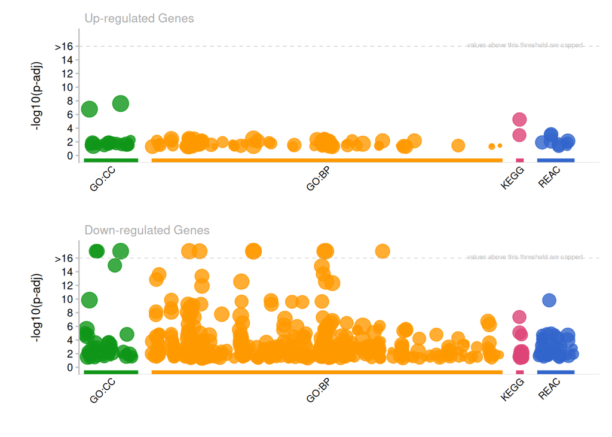

```r
if(!requireNamespace("patchwork", quietly = TRUE)) {
  install.packages("patchwork")
}
library(gprofiler2)
library(patchwork)

# Interactive plot (zoomable, hover for gene info)
p_up <- gostplot(
  upreg_ora,
  capped = TRUE,
  interactive = FALSE
)
p_down <- gostplot(
  downreg_ora,
  capped = TRUE,
  interactive = FALSE
)

p_up / p_down
```

**Figure 1. Manhattan plots showing enriched biological processes and pathways for up-regulated (top) and down-regulated (bottom) genes in human neural progenitor cells (NPC).** The analyzed genes represent those potentially regulated by UPF3B, identified through differential expression analysis between UPF3B-KO and Ctrl samples. ORA was performed using *GO-BP*, *GO-CC*, *KEGG*, and *REAC* Reactome databases with FDR < 0.05, excluding electronically inferred annotations (IEA). Each point represents a significantly enriched term, with the y-axis showing -log10(FDR).

## 2.3 Extract results

### 2.3.1 Filtering results according to thresholds

To improve the robustness of enrichment results, pathway terms were filtered using predefined thresholds. Gene sets with fewer than 5 or more than 500 genes were excluded, and only terms with an intersection size of at least 2 genes with the query list were retained. After applying these criteria, 73 significantly enriched pathways were identified for the up-regulated gene set and 388 for the down-regulated gene set.

```r
# extract the results dataframe for up- and down-regulated genes
# set thresholds
min_gs_size = 5
max_gs_size = 500    # adjust to improve robustness of enrichment results
min_intersec = 2

# apply filtering thresholds on term sizes
up_result_filtered <- upreg_ora$result %>%
  filter(term_size >= min_gs_size,
         term_size <= max_gs_size,
         intersection_size >= min_intersec)
down_result_filtered <- downreg_ora$result %>%
  filter(term_size >= min_gs_size,
         term_size <= max_gs_size,
         intersection_size >= min_intersec)

# message
up_pathways <- nrow(up_result_filtered)
down_pathways <- nrow(down_result_filtered)
cat("Significant up-regulated pathways:", up_pathways,
    "\nSignificant down-regulated pathways:", down_pathways)
```

```
## Significant up-regulated pathways: 73
## Significant down-regulated pathways: 388
```

### 2.3.2 Top 10 up-regulated pathways

```r
if(!requireNamespace("kableExtra", quietly = TRUE)) {
  install.packages("kableExtra")
}
library(kableExtra)

# keep only columns needed (avoiding list columns)
keep_cols <- c("term_id", "term_name",
               "p_value", "intersection_size")
up_subset <- up_result_filtered[, keep_cols]

# select top 10
up_top10 <- up_subset %>%
  arrange(p_value) %>%
  slice(1:10)

# modify p_value format
up_top10$p_value <- formatC(up_top10$p_value, format = "e", digits = 2)

# render table of top 10
knitr::kable(up_top10,
             row.names = FALSE,
             format = "html",
             caption = "Top 10 significantly up-regulated functional terms/pathways") %>%
  kable_styling(
    bootstrap_options = c("striped", "condensed"),
    full_width = FALSE) %>%
  column_spec(2, width = "30em")
```

Top 10 significantly up-regulated functional terms/pathways

| term_id | term_name | p_value | intersection_size |
| --- | --- | --- | --- |
| KEGG:04080 | Neuroactive ligand-receptor interaction | 5.30e-06 | 21 |
| REAC:R-HSA-500792 | GPCR ligand binding | 8.21e-04 | 22 |
| KEGG:04020 | Calcium signaling pathway | 1.03e-03 | 14 |
| REAC:R-HSA-416476 | G alpha (q) signalling events | 1.05e-03 | 14 |
| GO:0007200 | phospholipase C-activating G protein-coupled receptor signaling pathway | 3.73e-03 | 10 |
| GO:0048729 | tissue morphogenesis | 3.73e-03 | 17 |
| GO:0048732 | gland development | 3.73e-03 | 11 |
| GO:0048534 | hematopoietic or lymphoid organ development | 3.73e-03 | 6 |
| GO:0050926 | regulation of positive chemotaxis | 3.73e-03 | 5 |
| GO:0050918 | positive chemotaxis | 5.12e-03 | 6 |

**Table 1. Top 10 significantly enriched functional terms and pathways for up-regulated genes.** Terms were filtered by gene set size (5-500 genes) and minimum intersection size (>=2 genes), and ranked by p-value.

### 2.3.3 Top 10 down-regulated pathways

```r
library(kableExtra)

down_subset <- down_result_filtered[, keep_cols]

# select top 10
down_top10 <- down_subset %>%
  arrange(p_value) %>%
  slice(1:10)

# modify p_value format
down_top10$p_value <- formatC(down_top10$p_value, format = "e", digits = 2)

# render table of top 10
knitr::kable(down_top10,
             row.names = FALSE,
             format = "html",
             caption = "Top 10 significantly down-regulated functional terms/pathways") %>%
  kable_styling(
    bootstrap_options = c("striped", "condensed"),
    full_width = FALSE) %>%
  column_spec(2, width = "30em")
```

Top 10 significantly down-regulated functional terms/pathways

| term_id | term_name | p_value | intersection_size |
| --- | --- | --- | --- |
| GO:0031012 | extracellular matrix | 4.22e-21 | 69 |
| GO:0030312 | external encapsulating structure | 4.22e-21 | 69 |
| GO:0062023 | collagen-containing extracellular matrix | 1.18e-15 | 52 |
| GO:0001568 | blood vessel development | 1.42e-13 | 58 |
| GO:0003013 | circulatory system process | 1.39e-10 | 50 |
| REAC:R-HSA-1474244 | Extracellular matrix organization | 1.53e-10 | 41 |
| GO:0048514 | blood vessel morphogenesis | 2.26e-10 | 50 |
| GO:0030198 | extracellular matrix organization | 2.36e-10 | 35 |
| GO:0043062 | extracellular structure organization | 2.54e-10 | 35 |
| GO:0045229 | external encapsulating structure organization | 2.75e-10 | 35 |

**Table 2. Top 10 significantly enriched functional terms and pathways for down-regulated genes.** Terms were filtered by gene set size (5-500 genes) and minimum intersection size (>=2 genes), and ranked by p-value.

## 2.4 Interpretation of results

Here in this assignment, *up-regulated* genes refer to those with higher expression in the **UPF3B-KO** (knockout) group compared with the **Ctrl** (control) group, while *down-regulated* genes have lower expression in the **UPF3B-KO** group.

```r
if(!requireNamespace("stringr", quietly = TRUE)) {
  install.packages("stringr")
}
library(dplyr)
library(stringr)

# try searching terms/pathways related to neuro-development
up_neuro_terms <- up_subset %>%
  filter(str_detect(term_name, regex("neuro", ignore_case = TRUE))) %>%
  arrange(p_value)
down_neuro_terms <- down_subset %>%
  filter(str_detect(term_name, regex("neuro", ignore_case = TRUE))) %>%
  arrange(p_value)
```

### 2.4.1 Summary of ORA Results

ORA was conducted separately for up-regulated and down-regulated genes in the UPF3B knockout versus control samples, with terms filtered by gene set size (5-500 genes) and a minimum intersection size of 2 genes. Using these criteria, **73** pathways were found to be significantly enriched among up-regulated genes, whereas **388** pathways were significantly enriched among down-regulated genes, reflecting a broader and more pronounced effect on gene repression than activation.

Notably, the down-regulated pathways included a substantial number of extra-cellular matrix (ECM) and vascular-related processes (as shown in **Table 2.**), such as extra-cellular matrix organization, collagen-containing ECM, blood vessel development, and circulatory system processes.

In addition, neural-related pathways, including neuron projection, dopaminergic neuron differentiation, and regulation of neurogenesis, were significantly down-regulated (as shown in **Table 4.**). Up-regulated pathways were enriched for neurotransmitter receptor complexes and synaptic signaling, suggesting selective transcript accumulation. Overall, these results indicate that UPF3B knockout affects diverse biological processes in a pathway-specific manner, with particularly strong effects on both **neural and extra-cellular matrix-related functions**.

```r
library(kableExtra)
knitr::kable(up_neuro_terms,
             row.names = FALSE,
             format = "html",
             caption = "up-regulated neural-related pathways/functional terms") %>%
  kable_styling(
    bootstrap_options = c("striped", "condensed"),
    full_width = FALSE) %>%
  column_spec(2, width = "30em")
```

up-regulated neural-related pathways/functional terms

| term_id | term_name | p_value | intersection_size |
| --- | --- | --- | --- |
| KEGG:04080 | Neuroactive ligand-receptor interaction | 0.0000053 | 21 |
| REAC:R-HSA-112316 | Neuronal System | 0.0241016 | 16 |
| GO:0098878 | neurotransmitter receptor complex | 0.0382932 | 4 |
| REAC:R-HSA-112314 | Neurotransmitter receptors and postsynaptic signal transmission | 0.0421370 | 10 |

**Table 3. ORA of up-regulated genes in UPF3B knockout samples highlighting neural-related pathways.** The table lists significantly enriched terms associated with neurotransmitter receptor complexes, neuroactive ligand-receptor interactions, and postsynaptic signal transmission, indicating selective accumulation of synaptic and neuronal transcripts following UPF3B loss.

```r
library(kableExtra)
knitr::kable(down_neuro_terms,
             row.names = FALSE,
             format = "html",
             caption = "down-regulated neural-related pathways/functional terms") %>%
  kable_styling(
    bootstrap_options = c("striped", "condensed"),
    full_width = FALSE) %>%
  column_spec(2, width = "30em")
```

down-regulated neural-related pathways/functional terms

| term_id | term_name | p_value | intersection_size |
| --- | --- | --- | --- |
| KEGG:04080 | Neuroactive ligand-receptor interaction | 0.0000081 | 36 |
| GO:0044306 | neuron projection terminus | 0.0003634 | 12 |
| GO:0007272 | ensheathment of neurons | 0.0030640 | 11 |
| GO:0043025 | neuronal cell body | 0.0053345 | 19 |
| GO:0071542 | dopaminergic neuron differentiation | 0.0106984 | 6 |
| GO:0050905 | neuromuscular process | 0.0167504 | 9 |
| GO:0050767 | regulation of neurogenesis | 0.0187927 | 17 |
| REAC:R-HSA-112316 | Neuronal System | 0.0206791 | 28 |
| GO:0005883 | neurofilament | 0.0398329 | 3 |

**Table 4. ORA of down-regulated genes in UPF3B knockout samples highlighting neural-related pathways.** The table lists significantly enriched terms related to neuron projection, neuronal cell body, dopaminergic neuron differentiation, and regulation of neurogenesis, reflecting suppression of neural development and differentiation processes upon UPF3B loss.

### 2.4.2 Neural Pathway Dysregulation

Focusing on neuro-developmental processes, down-regulated gene sets were enriched for neuron projection terminus, neuronal cell body, dopaminergic neuron differentiation, and regulation of neuro-genesis, reflecting suppression of neural development and differentiation pathways (Alrahbeni et al., 2015).

Up-regulated gene sets, by contrast, were enriched for neurotransmitter receptor complexes, neuroactive ligand-receptor interactions, and post-synaptic signal transmission, suggesting that specific synaptic components may accumulate due to reduced NMD activity. This bidirectional pattern highlights that UPF3B knockout selectively impacts neural transcript stability, consistent with the notion that NMD targets are factor- and cell type-specific (Tan et al., 2025), rather than globally suppressed.

### 2.4.3 Integration with Published Evidence

Independent studies further validate these findings. UPF3B mutations have been associated with neuro-developmental disorders (Jolly et al., 2013), cognitive impairments (Alrahbeni et al., 2015), and synaptic dysfunction, supporting the observed down-regulation of neuronal differentiation pathways in our analysis.

Additionally, NMD has been shown to regulate synaptic receptor composition and post-synaptic signaling, aligning with the up-regulated neurotransmitter receptor complexes detected in our analysis. ECM and vascular-related transcript regulation has also been reported in contexts where NMD influences structural gene expression (Chamieh et al., 2008), further supporting the broader biological relevance of our ORA results. Together, these findings highlight the pathway-specific, pleiotropic effects of UPF3B knockout.

# 3 Non-thresholded gene set enrichment analysis (GSEA)

## 3.1 Fetching .gmt file

> Note: Firstly, I attempted to use the current release version (Mar. 02, 2026); however, errors occurred when loading the GMT file in the GSEA application due to duplicate gene set names. Therefore, an alternative gene set collection without duplicate pathway names was used for the subsequent analysis.

This file contains all Gene Ontology (GO) pathways across biological processes, molecular functions, and cellular components, represented by gene symbols. We specifically chose the version without parent–child overlap correction (noPFOCR) to retain the full hierarchical structure of GO terms, and without IEA (Inferred from Electronic Annotation) evidence to ensure high-confidence annotations. This selection balances comprehensive coverage of relevant GO pathways with reliable, experimentally supported gene annotations, enhancing the interpretability of the enrichment results.

```r
if(!requireNamespace("RCurl", quietly = TRUE)) {
  install.packages("RCurl")
}
library(RCurl)

# select current release - Mar.02
gmt_file_name <- "Human_GO_AllPathways_noPFOCR_no_GO_iea_September_01_2025_symbol.gmt"
setwd("/home/rstudio/projects/A2")
data_dir <- "./data"

# set download directory
if(!dir.exists(data_dir)) dir.create(data_dir)
dest_gmt_file <- file.path(data_dir, gmt_file_name)

# URL for download
gmt_url <- paste0("http://download.baderlab.org/EM_Genesets/September_01_2025/Human/symbol/", gmt_file_name)

# download GMT file if not already present
if(!file.exists(dest_gmt_file)){
  message("Downloading GMT file to: ", dest_gmt_file)
  download.file(gmt_url, destfile = dest_gmt_file, mode = "wb")
} else {
  message("GMT file already exists: ", dest_gmt_file)
}
```

## 3.2 Generating .rnk file

We generated a `.rnk` file containing all genes from the differential expression analysis in Assignment 1. Each gene was assigned a ranking score calculated as the sign of the log2 fold-change multiplied by the negative log10 of the p value corrected using FDR:
$$\text{rank} = \text{sign}(\text{logFC}) \times -\log_{10}(\text{FDR
adjusted pValue})$$
Positive values indicate genes up-regulated in the condition of interest, whereas negative values indicate down-regulated genes.

This ranking strategy was chosen to capture both the **direction and statistical significance of differential expression**, ensuring that genes with small but highly significant changes contribute appropriately to enrichment analysis. Using this approach allows non-thresholded GSEA to leverage information from all measured genes, rather than only those passing arbitrary significance cutoffs, increasing the sensitivity and interpretability of pathway-level results.

```r
library(dplyr)

setwd("~/projects/A2")
results_DEA <- read.csv("data/DEA_result.csv", stringsAsFactors = FALSE)

ranked_genes <- results_DEA %>%
  mutate(rank = sign(logFC) * (-log10(FDR))) %>%
  # keep only two required columns
  dplyr::select(gene_name, rank) %>%
  arrange(desc(rank))

# save .rnk file into data dir
data_dir <- "./data"
rnk_file <- file.path(data_dir, "pre_GSEA_rank.rnk")

if (!file.exists(rnk_file)) {
  write.table(ranked_genes,
            file = rnk_file,
            sep = "\t", row.names = FALSE, col.names = FALSE, quote = FALSE)
  message("DEA CSV file created: ", rnk_file)
} else {
  message("DEA File already exists, skipping write: ", rnk_file)
}

paged_table(ranked_genes[1:10, ] )
```

|  | gene_name | rank |
| --- | --- | --- |
| 1 | ANGPTL7 | 33.90327 |
| 2 | GNAS | 28.27420 |
| 3 | PI15 | 27.66030 |
| 4 | NRCAM | 25.86643 |
| 5 | TNC | 25.30511 |
| 6 | GAS5 | 25.30511 |
| 7 | ANO1 | 24.20063 |
| 8 | PEA15 | 24.06108 |
| 9 | COL8A1 | 23.92648 |
| 10 | NBPF9 | 23.35058 |

## 3.3 GSEA process

Our analysis workflow was adapted from the CBW Pathway Workshop framework (Isserlin, 2024), with several adjustments and customizations applied to suit the specific needs of this study. The process was performed using the GSEA desktop software version 4.4.0.

### 3.3.1 Parameters

**GSEA desktop version:** v4.4.0

**Geneset database:** Human_GO_AllPathways_noPFOCR_no_GO_iea_September_01_2025_symbol.gmt

**Number of permutations:** 2000

**Ranked DEGs:** pre_GSEA_rank.rnk

**Collapse/Remap to gene symbols:** No_Collapse

**Max size:** 500

**Min size:** 15

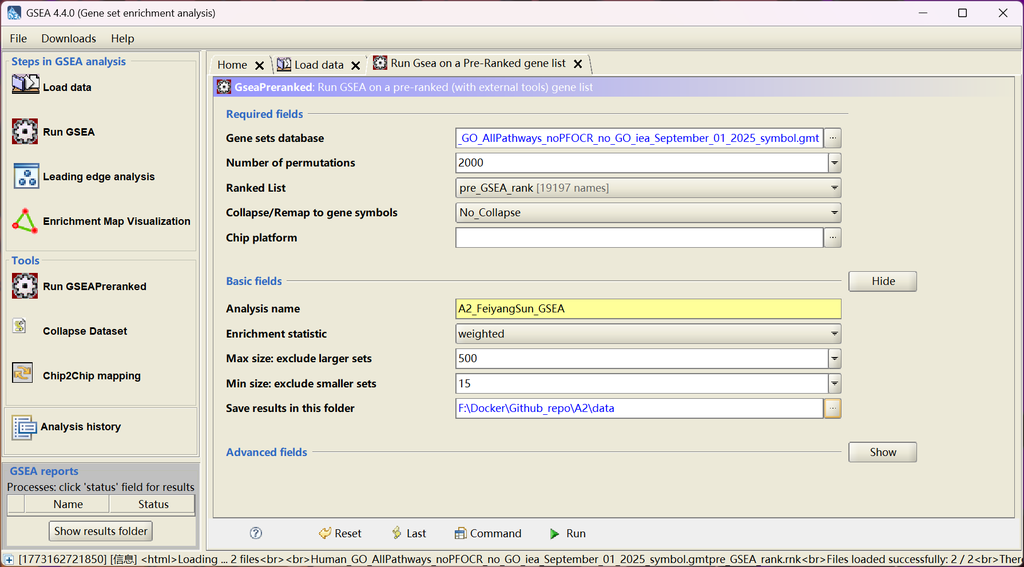

Scree shot for GSEA parameters

**Figure 2. Screenshot of the parameter settings used for the GSEA analysis.** The interface displays key configuration options including the number of permutations, selection of the ranked gene list file, and the option to disable gene symbol remapping since the ranked list already contains gene symbols. Additional settings shown include the specification of an analysis name to label the output directory, adjustment of gene set size filters to exclude excessively large or small pathways, and selection of the output directory where GSEA saves the analysis results.